# Communicate Data Insights: Ford GoBike System Data (Part 2/2)

## by Brian Kogi

## Investigation Overview

In this presentation, I focus on:

1. The number of subscribers compared to the number of customers.
2. Distribution of Duration in Minutes
3. Ratio of Gender in Population
4. Hourly Average Distribution of Trips Between Weekdays And Weekends
5. Hourly Average Trip Duration Between Customers and Subscribers

## Dataset Overview

The Dataset consists of information regarding 183411 bike trips for the month of February, including its timing and geolocation of the start and end of each trip. The dataset 2017-fordgobike-tripdata.csv can be downloaded [here](https://video.udacity-data.com/topher/2020/October/5f91cf38_201902-fordgobike-tripdata/201902-fordgobike-tripdata.csv).

## Number of subscribers compared to the number of customers

Here, we compare the number of subscribers compared to the number of customers. We can see that subscribers are more than customers by a huge margin.

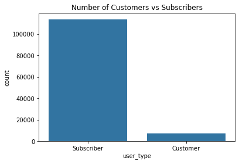

## Distribution of Duration

Here we observe the longevity of the trips in minutes and we can see that most trips are longer than 5 minutes with the highest time being 12 minutes. This hints that the destinations are not that far apart or most people use other means of transport when travelling longer distances.

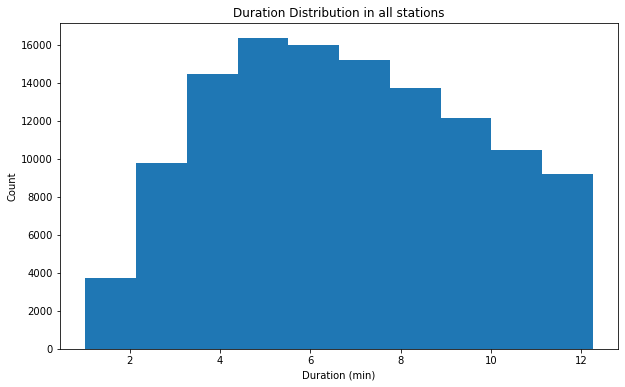

## Ratio of Gender in Population

Here we observe that a majority of trips are started by men, with females making up less than a quarter of the population of users

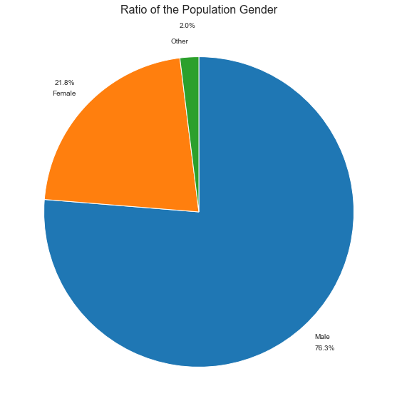

## Hourly Average Distribution of Trips Between Weekdays And Weekends

The two graphs below depict the overall distribution of started trips during the day in weekdays and during the weekends. From the two distributions, we can see that during weekdays, the distribution is bimodal as most people start trips early in the morning or in the evening. We can also see that in the weekends, most trips start from 11:00am till evening.

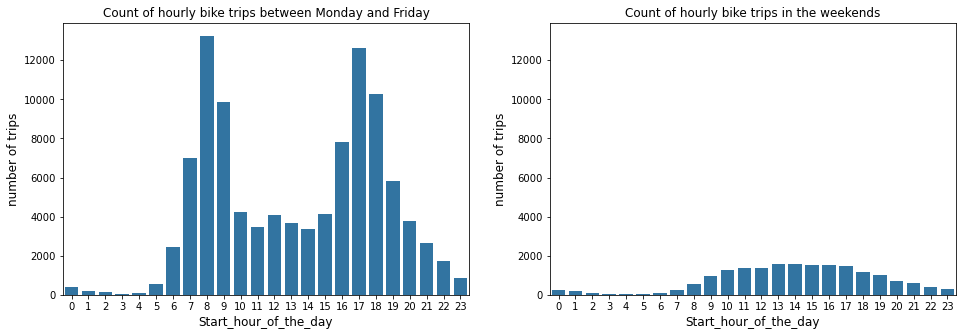

## Hourly Average Trip Duration Between Customers and Subscribers

This graph below tracks the difference between the average trip durations between customers and subscribers, we find that customers make longer trips on average during the day compared to subscribers, this is could be due to the lower number hence less variations in trip time or other reasons.

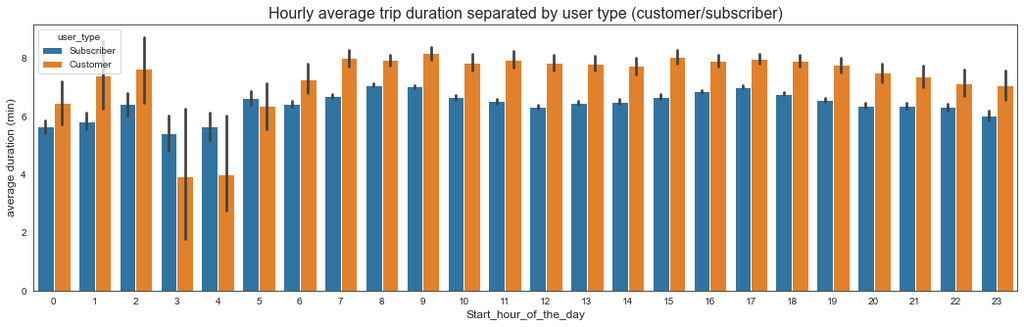